# NFL EDA - J

Justin Eldridge

2024-11-13

# EDA for Justin to work on to avoid repo desync

#Try to select a model to predict pass vs. run

```r
#load in the tracking data for week 1
track1_df <- read.csv("data/presnap_events_week_1.csv")

#Explor the variables available to us
colnames(track1_df)
```

```
##  [1] "gameId"        "playId"        "nflId"         "displayName"
##  [5] "frameId"       "frameType"     "time"          "jerseyNumber"
##  [9] "club"          "playDirection" "x"             "y"
## [13] "s"             "a"             "dis"           "o"
## [17] "dir"           "event"
```

```r
#Load in the plays and games data to explore the variables
plays_df <- read.csv("data/plays.csv")

#View the variables avaialble to get a sense if what to explore
colnames(plays_df)
```

```
##  [1] "gameId"                           "playId"
##  [3] "playDescription"                  "quarter"
##  [5] "down"                             "yardsToGo"
##  [7] "possessionTeam"                   "defensiveTeam"
##  [9] "yardlineSide"                     "yardlineNumber"
## [11] "gameClock"                        "preSnapHomeScore"
## [13] "preSnapVisitorScore"              "playNullifiedByPenalty"
## [15] "absoluteYardlineNumber"           "preSnapHomeTeamWinProbability"
## [17] "preSnapVisitorTeamWinProbability" "expectedPoints"
## [19] "offenseFormation"                 "receiverAlignment"
## [21] "playClockAtSnap"                  "passResult"
## [23] "passLength"                       "targetX"
## [25] "targetY"                          "playAction"
## [27] "dropbackType"                     "dropbackDistance"
## [29] "passLocationType"                 "timeToThrow"
## [31] "timeInTackleBox"                  "timeToSack"
## [33] "passTippedAtLine"                 "unblockedPressure"
## [35] "qbSpike"                          "qbKneel"
## [37] "qbSneak"                          "rushLocationType"
## [39] "penaltyYards"                     "prePenaltyYardsGained"
## [41] "yardsGained"                      "homeTeamWinProbabilityAdded"
## [43] "visitorTeamWinProbilityAdded"     "expectedPointsAdded"
## [45] "isDropback"                       "pff_runConceptPrimary"
## [47] "pff_runConceptSecondary"          "pff_runPassOption"
## [49] "pff_passCoverage"                 "pff_manZone"
```

## Brainstorm on variables to include

playid- to see what the previous play was to do a lag (i.e. if the previous run failed they are more liekly to do a pass)

time_remaining

yards remaining

score

maybe indicate if there was pre-snap movement can create magnitude vectors and take a difference for each one use x coordinates

orientation 360 where they ar facing

distance direction and orientation for pre-snap movement

If over a certain number indicate that pre-snap movement took place

want the sum of the distances traveled in each event before the snap

create our own distance column because they could still be moving even if their was no event. So when we removed the na values we removed some of the distances traveled before the snap

possibly filter out play with distance <0.1

Need to change the data cleaning file

to do lag on play we might have to sort by game ID, play id

red_zone

possibly come back and make a function to calculate the teams record

should exclude plays with a penalty would introduce too much error

exclude qbkneels,

Indicator for significant pre-snap movement time remaining yards remaining score red-zone play_id game_id play-concept lag See if the teams current record is available prensnap home and visitor score from the plays data designed sneaks included don’t include forced sneaks might be captured in run runpassoption

either have to exclude rpo (don’t happen often enough), or can include in prediction model as either run pass or rpo typcially fairly rare

svm wouldnt be good for 3 classifiers, best for binary classifier

or consider RPO vs run run 1st pass 2nd if the run isnt there then throw i so we would consider this a run play Consider and rpo to be a run play if we do this just call them runs and then we could still use svm for the binary run pass classifier

every rpo has a primary run concept pff thingy so we could use that column to classifiy

Break the data down into individual drives otherwise an epa lag will consider the other teams score in the new drive.

rpo the qb chooses as the play unfolds whether hes going to pass or run

pass_length to try and get and indicator varialbe could use rush_location_type

runconcept primary sometiems show as having one even if its a pass bc of designed rollout in dropback type have a run concept associated for some reason

can use droback type as better indicator of pass -traditional scrabmle for passes, desgined rollouts-passes, elminiate unknown dropback types

calculate yard to endzone because data fails to account for the 10 yards in the endzone(based on yard number) -dont use yardstogo

2nd draft of variables:

time remaining score yards remaining epa lag (break down into drives so lag works properly) run/pass indicator (include runpass options as runs so we can do svm, designed qb sneaks as runs scrambles as passes) play-concept lag red_zone game_id play_id indicator var for significant pre-snap movement pre-snap home and visitor score

–they have var with game clock which resets every quarter might be able to make a function that takes game clock and gives us the amount of seconds remaining until end of the half

to do:

some eda

how man runs vs. passes how often certain events occur look for rare events how many rpos end up as passes

do svm for offense

might do random forrest for defense two binary classifiers create 4 possile situtations

data cleaning:

– make a function to convert the game clock into seconds remaining in the half. –play data, time on clock of play in minutes seconds.

work on cleaning for the presnap events- use game id and play id to join the data, to attach cleaned data to the plays data

neeed out of presnap, which player is moving on the offense club is going to get joined onto possession team whichever team has possession find which players are moving

1 .Explore the data to figure out what events are more or less rare

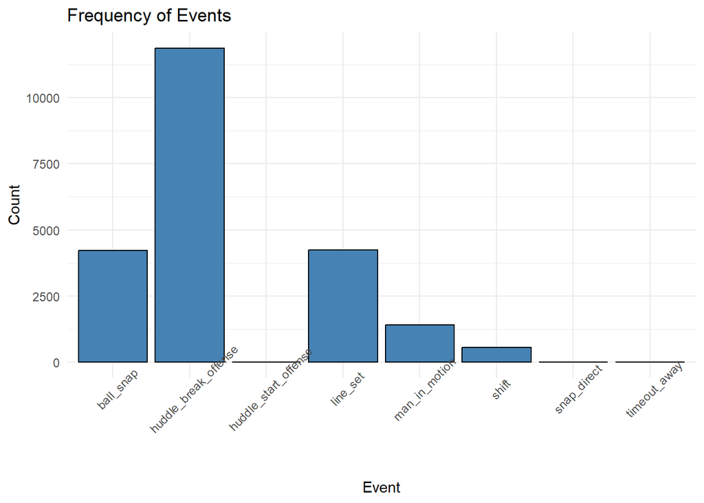

```r
#####
# 1 #
#####

#Filter out the na values from the data so we can figure out the frequency of
#events

# Filter out NA values from the event column
wk1_events <- track1_df[!is.na(track1_df$event), ]

# Create a bar plot of events (use geom_bar for categorical data)
event_hist <- wk1_events %>%
  ggplot(aes(x = event)) +
  geom_bar(fill = "steelblue", color = "black") +
  theme_minimal() +
  labs(
    title = "Frequency of Events",
    x = "Event",
    y = "Count"
  )+
  #Rotate the axis labels to make them more readable
  theme(axis.text.x= element_text(angle=45))

# Display the plot
event_hist
```

```r
#Shift is when the whole offense changes formation
#Man in motion is when one man moves across but the formation remains the same
```

Look up each of the event descriptions. Specifically look at what the man_in_motion event means

Not finding anything useful in the kaggle description Depending on what man in motion means we might want to use that instead of our indicator variables because then we wouldn’t have to worry about the na values

## 2 Data joining

Use the game_id and play_id to try and join the cleaned tracking data into the plays data.

```r
#####
# 2 #
#####

#Load in the plays data and glance at it to get an idea of how to join it to
#the tracking data
play_glance <-head(plays_df, n=15)
track_glance <-head(track1_df)


#Try the simple approach of joining the week 1 tracking data with the
#plays data by gameID and playID

# Perform an inner join on gameId and playId
merged_data <- track1_df %>%
  inner_join(plays_df, by = c("gameId", "playId"))

#Take a look at the resulting dataset and see if it looks right.
head(merged_data)
```

```
##       gameId playId nflId    displayName frameId   frameType
## 1 2022091200     64 35459 Kareem Jackson     114        SNAP
## 2 2022091200     64 39987     Geno Smith      39 BEFORE_SNAP
## 3 2022091200     64 39987     Geno Smith      40 BEFORE_SNAP
## 4 2022091200     64 39987     Geno Smith      41 BEFORE_SNAP
## 5 2022091200     64 39987     Geno Smith      42 BEFORE_SNAP
## 6 2022091200     64 39987     Geno Smith      43 BEFORE_SNAP
##                    time jerseyNumber club playDirection     x     y    s    a
## 1 2022-09-13 00:16:14.8           22  DEN         right 50.29 29.43 1.13 1.62
## 2 2022-09-13 00:16:07.3            7  SEA         right 35.76 23.93 1.06 0.51
## 3 2022-09-13 00:16:07.4            7  SEA         right 35.87 23.95 1.08 0.47
## 4 2022-09-13 00:16:07.5            7  SEA         right 35.98 23.97 1.11 0.31
## 5 2022-09-13 00:16:07.6            7  SEA         right 36.09 23.99 1.12 0.19
## 6 2022-09-13 00:16:07.7            7  SEA         right 36.20 24.01 1.14 0.01
##    dis      o    dir     event
```

[output cut: 90 more lines]

```r
#Ok that seems to work super well. Have chanlder take a look at it to make sure
#nothing is being lost or if I'm missing something obvious.

#Looking ahead not sure if it will be advantageous to add all of the tracking data into the plays data
```

So we are able to join the tracking data to the plays data. Now look at the code chandler used to do some cleaning and create our indicator variables.

Once I can get those joined I can find out how frequent runs vs. passes are

## 3. Run Chandlers code for cleaning and such and then try to merge the datasets

```r
#####
# 3 #
#####

plays <- read.csv("data/plays.csv")

presnap_1 <- read.csv("data/presnap_events_week_1.csv")

week_1_plays <- plays %>% filter(gameId %in% presnap_1$gameId,
                                 playNullifiedByPenalty == "N",
                                 qbKneel == 0,
                                 (dropbackType != "UNKNOWN" | is.na(dropbackType))) %>%
  arrange(gameId, playId) %>%
  mutate(run_pass = case_when(pff_runPassOption == 1 ~ "run",
                              is.na(dropbackType) ~ "run",
                              str_detect(dropbackType, "RUN|SNEAK") ~ "run",
                              T ~ "pass"),
         yards_to_endzone = ifelse(possessionTeam == yardlineSide, abs(yardlineNumber - 100), yardlineNumber),
         redzone = ifelse(yards_to_endzone <= 20, T, F),
         half = ifelse(quarter <= 2, 1, 2),
         sec_in_half = ((as.numeric(str_extract(gameClock, "[:digit:]+(?=:)")) * 60) + as.numeric(str_extract(gameClock, "(?<=:)[:digit:]+"))) + ifelse(quarter %in% c(1, 3), 900, 0))

week_1_plays$new_half <- week_1_plays$half != c(0, week_1_plays$half[-nrow(week_1_plays)])
week_1_plays$new_game <- week_1_plays$gameId != c(0, week_1_plays$gameId[-nrow(week_1_plays)])
week_1_plays$new_possession <- (week_1_plays$possessionTeam != c(0, week_1_plays$possessionTeam[-nrow(week_1_plays)])) | week_1_plays$new_half

# set first row of variables
teams <- c(week_1_plays$possessionTeam[1], week_1_plays$defensiveTeam[1])
drive <- c(1, 0)
names(drive) <- teams
week_1_plays$drive <- c(1, rep(0, nrow(week_1_plays) - 1))

# loop through rows 2 to end of df
for(i in c(2:nrow(week_1_plays))){
  if(week_1_plays$new_game[i]){
    teams <- c(week_1_plays$possessionTeam[i], week_1_plays$defensiveTeam[i])
    drive <- c(1, 0)
    names(drive) <- teams
  }
  else if(week_1_plays$new_possession[i]){
    drive[week_1_plays$possessionTeam[i]] <- drive[week_1_plays$possessionTeam[i]] + 1
  }
  week_1_plays$drive[i] <- drive[week_1_plays$possessionTeam[i]]
}

# week_1_plays[,c("possessionTeam", "new_possession", "drive", "new_half")]
```

## 4. Create indicator varaibles for run/pass and determine which is more common

```r
#####
# 4 #
#####

# # Create a new data frame by filtering out rows where dropbackType is NA or UNKNOWN
# filtered_data <- plays_df %>%
#   filter(!is.na(dropbackType) & dropbackType != "UNKNOWN")
#
# # Create the indicator variable
#
# #Run if -designed run or qb_sneak
# #Pass if - traditional, scramble, or contains "ROLLOUT"
#
# filtered_data <- filtered_data %>%
#   mutate(run_pass_ind = case_when(
#     dropbackType %in% c("TRADITIONAL", "SCRAMBLE") | str_detect(dropbackType, "ROLLOUT") ~ 0,
#     dropbackType %in% c("QB_SNEAK", "DESIGNED_RUN") ~ 1,
#     TRUE ~ NA_real_ #for safety
#   ))
#
# # Check the first few rows to ensure it worked
# head(filtered_data)
#
#
# #Plot the frequency of each type run vs. pass
# run_pass_plot <- filtered_data %>%
#   ggplot( aes(x = factor(run_pass_ind), fill = factor(run_pass_ind))) +
#   geom_bar() +
#   scale_x_discrete(labels = c("0" = "Pass", "1" = "Run")) +
#   labs(
#     x = "Play Type",
#     y = "Frequency",
#     title = "Frequency of Run and Pass Plays",
#     fill = "Play Type"
#   ) +
#   theme_minimal()
#
# #Display the plot
# run_pass_plot




# Treat NA values as "DESIGNED_RUN" and UNKNOWN values as "OTHER"
filtered_data <- plays_df %>%
  mutate(dropbackType = ifelse(is.na(dropbackType) | dropbackType == "UNKNOWN", "DESIGNED_RUN", dropbackType))

# Create the indicator variable
# Run if - DESIGNED_RUN or QB_SNEAK
# Pass if - TRADITIONAL, SCRAMBLE, or contains "ROLLOUT"

filtered_data <- filtered_data %>%
  mutate(run_pass_ind = case_when(
    dropbackType %in% c("TRADITIONAL", "SCRAMBLE") | str_detect(dropbackType, "ROLLOUT") ~ 0,
    # Pass
    dropbackType %in% c("QB_SNEAK", "DESIGNED_RUN") ~ 1,
    # Run
    TRUE ~ NA_real_
    # Safety fallback
  ))


# Check the first few rows to ensure it worked
head(filtered_data)
```

```
##       gameId playId
## 1 2022102302   2655
## 2 2022091809   3698
## 3 2022103004   3146
## 4 2022110610    348
## 5 2022102700   2799
## 6 2022100205   2314
##                                                                                 playDescription
## 1      (1:54) (Shotgun) J.Burrow pass short middle to T.Boyd to CIN 30 for 9 yards (J.Hawkins).
## 2  (2:13) (Shotgun) J.Burrow pass short right to H.Hurst to CIN 12 for 4 yards (L.Vander Esch).
## 3       (2:00) (Shotgun) D.Mills pass short right to D.Pierce to HST 26 for 6 yards (D.Walker).
## 4 (9:28) (Shotgun) P.Mahomes pass short left to I.Pacheco to TEN 19 for 4 yards (Z.Cunningham).
## 5              (2:16) (Shotgun) L.Jackson up the middle to TB 28 for -1 yards (R.Nunez-Roches).
## 6                  (14:15) Ja.Williams up the middle to DET 32 for 3 yards (C.Barton; U.Nwosu).
##   quarter down yardsToGo possessionTeam defensiveTeam yardlineSide
```

[output cut: 76 more lines]

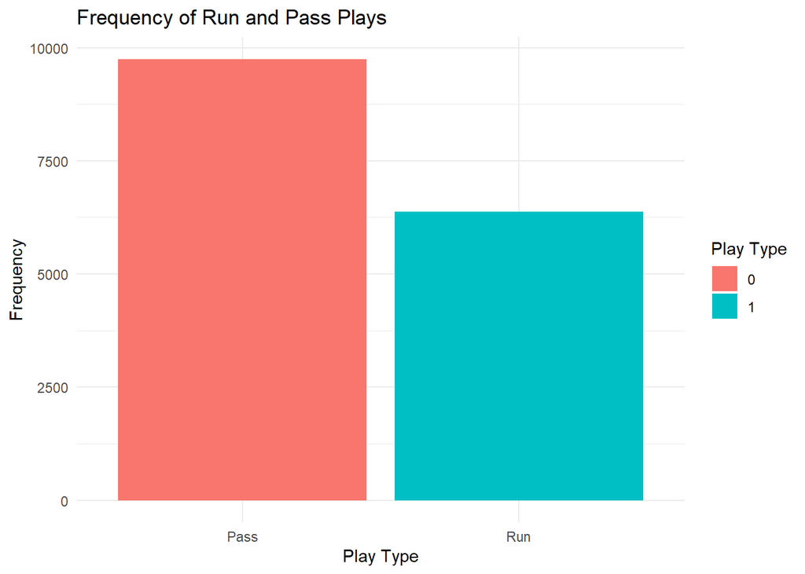

```r
# Plot the frequency of each type run vs. pass
run_pass_plot <- filtered_data %>%
  ggplot(aes(x = factor(run_pass_ind), fill = factor(run_pass_ind))) +
  geom_bar() +
  scale_x_discrete(labels = c("0" = "Pass", "1" = "Run")) +
  labs(
    x = "Play Type",
    y = "Frequency",
    title = "Frequency of Run and Pass Plays",
    fill = "Play Type"
  ) +
  theme_minimal()

# Display the plot
run_pass_plot
```

That frequency seems really suspsicious. Try doing the same thing for all dropback types and see what their frequencies are

## 5. Investigate the frequency of each dropback type

```r
#####
# 5 #
#####

#Create a histogram showing the frequency of each kind of dropback type

# Assign "OTHER" to rows where dropbackType is NA
other_df <- plays_df %>%
  mutate(dropbackType = ifelse(is.na(dropbackType), "OTHER", dropbackType))


#Plot the frequency of each dropbackType
drop_type_plot <- other_df %>%
  ggplot( aes(x = factor(dropbackType), fill = factor(dropbackType))) +
  geom_bar() +
  labs(
    x = "Dropback Type",
    y = "Frequency",
    title = "Frequency of Dropback Types",
    fill = "Play Type"
  ) +
  theme(axis.text.x=element_text(angle=90))
  theme_minimal()
```

[output not shown]

[output cut: 240 more lines]

[output not shown]

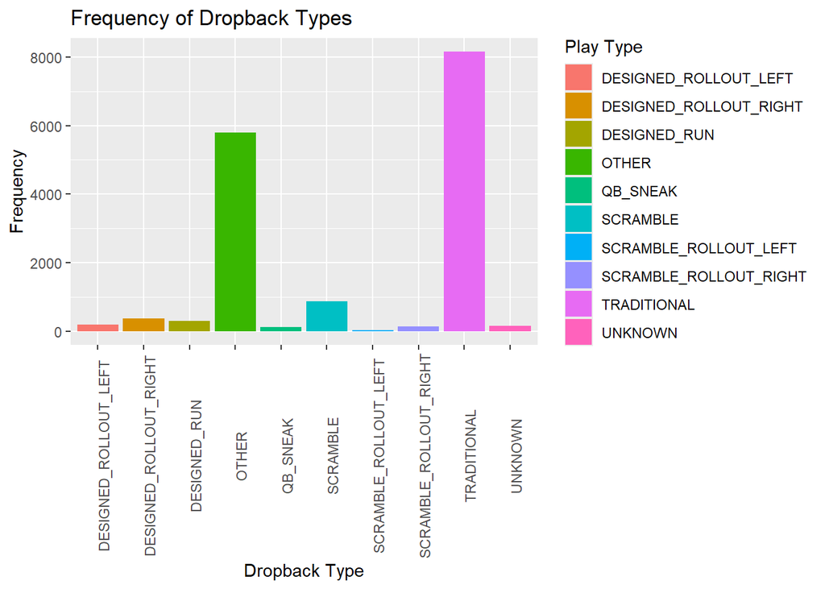

```r
#Display the plot
drop_type_plot
```

Look on the kaggle description to see if anything more specific is noted about the type.

UPDATE: ITs because the NA values are likely runs in actuality so removing them inflated the proportion of pass plays.

## 7. Need to find out which player on the offense is moving during presnap movement

Try this out using the merged data that I created in 2.

## 7 Try to figure out a way to figure out which player on the offense is moving

I’m hoping that I can find the man in motion and shift events to isolate plays that are relevant and then use some boundary to figure out which player is responsible for the movement

```r
#####
# 7 #
#####

#Create dummy data frames for experimenting
df7_plays <- plays_df
track1_df7 <- track1_df

#Merge the plays and tracking data
merged_df7 <- track1_df7 %>%
  inner_join(df7_plays, by = c("gameId", "playId"))

#Identify the relevant play ID's
   # i.e. plays that have a shift or man_in_motion event at some point during
   # the play.
relevant_play_ids <- merged_df7 %>%
  filter(event %in% c("man_in_motion", "shift")) %>%
  pull(playId)

#Create a data frame with just the relevant plays
filtered_df7 <- merged_df7 %>%
  filter(playId %in% relevant_play_ids)

#Calculate the average distance each player moved during the play
    #If all players have some degree of small noisy movement a simple sum might
    #be misleading since longer pre-snap times would artificially inflate the
    #distance traveled.

# Calculate the mean distance for each player for each play
mean_distance_df <- filtered_df7 %>%
  group_by(gameId, playId, displayName) %>%
  mutate(mean_dis = mean(dis, na.rm = TRUE)) %>%
  ungroup()

# View the results
head(mean_distance_df)
```

```
## # A tibble: 6 × 67
##       gameId playId nflId displayName frameId frameType time  jerseyNumber club
##        <int>  <int> <int> <chr>         <int> <chr>     <chr>        <int> <chr>
## 1 2022091200     85 35459 Kareem Jac…       1 BEFORE_S… 2022…           22 DEN
## 2 2022091200     85 35459 Kareem Jac…       2 BEFORE_S… 2022…           22 DEN
## 3 2022091200     85 35459 Kareem Jac…       3 BEFORE_S… 2022…           22 DEN
## 4 2022091200     85 35459 Kareem Jac…       4 BEFORE_S… 2022…           22 DEN
## 5 2022091200     85 35459 Kareem Jac…       5 BEFORE_S… 2022…           22 DEN
## 6 2022091200     85 35459 Kareem Jac…       6 BEFORE_S… 2022…           22 DEN
## # ℹ 58 more variables: playDirection <chr>, x <dbl>, y <dbl>, s <dbl>, a <dbl>,
## #   dis <dbl>, o <dbl>, dir <dbl>, event <chr>, playDescription <chr>,
## #   quarter <int>, down <int>, yardsToGo <int>, possessionTeam <chr>,
## #   defensiveTeam <chr>, yardlineSide <chr>, yardlineNumber <int>,
## #   gameClock <chr>, preSnapHomeScore <int>, preSnapVisitorScore <int>,
## #   playNullifiedByPenalty <chr>, absoluteYardlineNumber <int>,
## #   preSnapHomeTeamWinProbability <dbl>, …
```

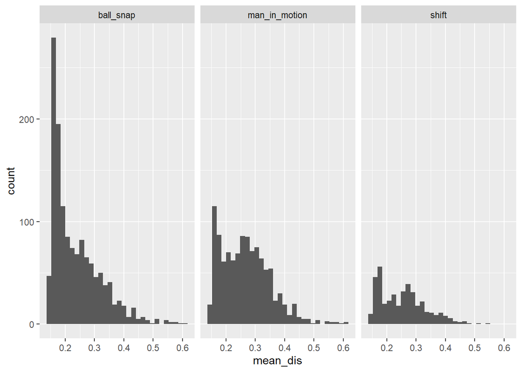

```r
#Remove the football display name as that is not a player
mean_distance_df <- mean_distance_df %>%
  filter(displayName !="football")

#Create a vector of events that we are most interested in
#Exclude:
#huddle_break_offense- not interested
#snap_direct- only 4 instances total and not sure what it means
#line_set- not interested in the motion of the offense getting to the line
valuable_events <- c("ball_snap", "man_in_motion", "shift")

#Plot the distribution of average distance traveled by event
mean_dist_plot <- mean_distance_df %>%
  #Play with some cutoff values to make sure that noisy shifting around isn't
  #included.
  filter(event %in% valuable_events, mean_dis >0.15) %>%
  ggplot()+
  geom_histogram(aes(x=mean_dis))+
  facet_wrap(~event)

#Display the plot
mean_dist_plot
```

```r
#Think about diff cutoff for each
#keep the peak for ball_snap because only one person should be moving
#shift is slower so we would have a different cutoff
#possible to universal cutoff of 0.05



#Now try to create a new column that displays the names of all the players who
#were moving during that play
high_dis_players <- mean_distance_df %>%
  filter(mean_dis >0.15)

#Add a column to the filtered data with the names of the players that were
#moving more than the cutoff on average

#something went wrong because it went up 1.6M observations so come back to fix
#this

# filtered_df7 <- filtered_df7 %>%
#   left_join(high_dis_players %>%
#               select(playId, gameId,displayName),
#             by=c("gameId", "playId","displayName")) %>%
#    mutate(high_mean_dis = ifelse(!is.na(displayName), displayName, NA_character_))
```